# Project 1 of Module 5

Download and load the dataset

```r
setwd("G:/My Drive/From Dropbox/Training/Data science specialization/Assignments/Module 5")

#Load the data

fileUrl <- "https://d396qusza40orc.cloudfront.net/repdata%2Fdata%2Factivity.zip"
download.file(fileUrl, file.path("./", "data.zip"))


# Unzip using WinRAR utility on Windows 8:
executable <- file.path("C:", "Program Files", "WinRAR", "WinRAR.exe")
cmd <- paste(paste0("\"", executable, "\""), "x",
             paste0("\"", file.path("./", "data.zip"), "\""))
system(cmd)
```

```
## [1] 0
```

```r
data <- read.csv("activity.csv", sep = ",")

#Create a folder for figures
if(!dir.exists("figure") == TRUE) dir.create("figure")
```

**What is mean total number of steps taken per day?** 1. Total number of steps taken per day

```r
dailystep <- tapply(data$steps, data$date, sum)
```

2. Histogram of daily steps

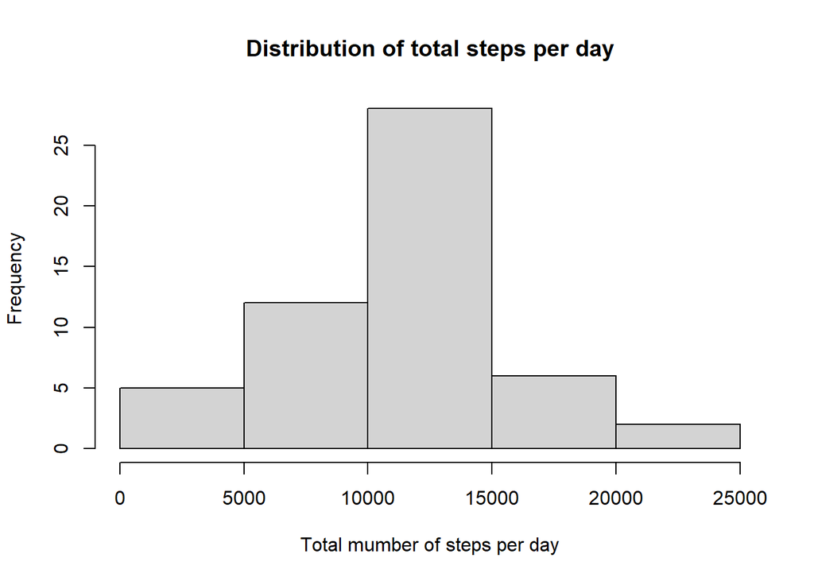

```r
hist(dailystep, xlab = "Total mumber of steps per day", main = "Distribution of total steps per day")
```

```r
png("./figure/totaldailysteps.png", width = 480, height = 480)
    hist(dailystep, xlab = "Total mumber of steps per day", main = "Distribution of total steps per day")
dev.off()
```

3. Mean and median of the total number of steps taken per day

```r
dailytotmean <- mean(dailystep, na.rm = TRUE)
dailytotmedian <- median(dailystep, na.rm = TRUE)
```

The mean for the total number of steps taken per day is **1.0766189^{4}** and the median is **10765**.

**What is the average daily activity pattern?**

1. Average of steps taken by 5-minute intervalle

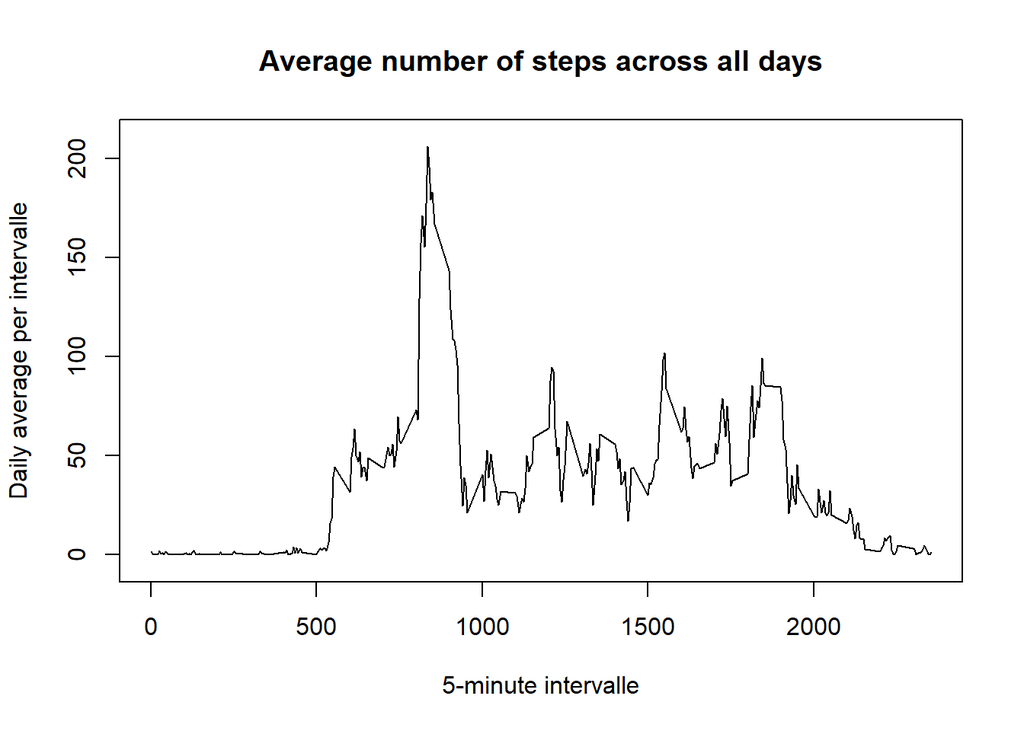

```r
# Compute the average of steps taken in each 5-minute intervalle across all days
dailystep_mean <- aggregate(data$steps, list(data$interval), na.rm = TRUE, mean)

plot(dailystep_mean$Group.1, dailystep_mean$x, type = "l", xlab = "5-minute intervalle", ylab = "Daily average per intervalle",
     main = "Average number of steps across all days",
     ylim=c(min(dailystep_mean$x, na.rm=TRUE)-5,
            max(dailystep_mean$x, na.rm=TRUE)+5))
```

```r
png("./figure/dailystep_mean.png", width = 480, height = 480)
plot(dailystep_mean$Group.1, dailystep_mean$x, type = "l", xlab = "5-minute intervalle", ylab = "Daily average per intervalle",
     main = "Average number of steps across all days",
     ylim=c(min(dailystep_mean$x, na.rm=TRUE)-5,
            max(dailystep_mean$x, na.rm=TRUE)+5))
dev.off()
```

```r
max5int <- dailystep_mean[which(grepl(max(dailystep_mean$x, na.rm=TRUE), dailystep_mean$x)), ]$Group.1
```

The maximum number of steps on average across all the days is in the 5-intervalle 835.

Imputing missing values

1.Number of rows with NAs.

```r
missval <-length(which(is.na(data$steps)))
```

The total number of rows with NAs is 2304.

2. Imputing missing values from overall mean

```r
dailystep_mean <- rename(dailystep_mean, interval = Group.1)
data_imputed <- left_join(data, dailystep_mean, by = "interval")
```

3. Create new dataset with the missing data filled in.

```r
data_imputed <- mutate(data_imputed,
                imputed = replace(data_imputed$steps, is.na(data_imputed$steps), data_imputed$x)
)
```

4. Histogram with imputed missing data

Total number of steps taken per day

```r
dailystep_imp <- tapply(data_imputed$imputed, data_imputed$date, sum)
```

Histogram of daily steps

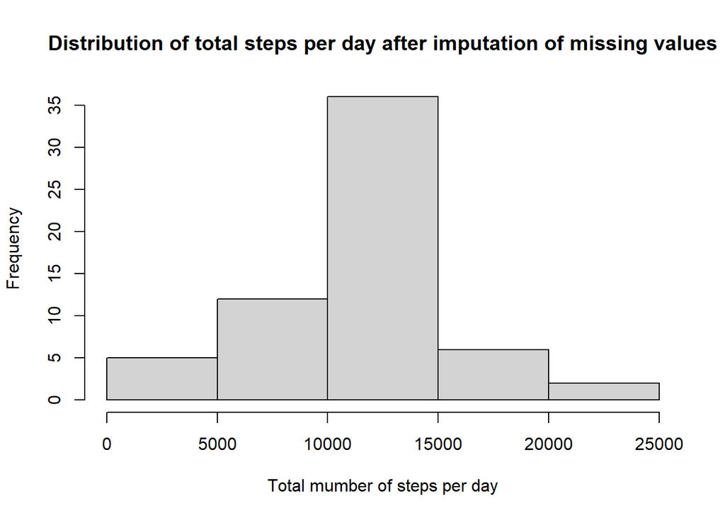

```r
hist(dailystep_imp, xlab = "Total mumber of steps per day", main = "Distribution of total steps per day after imputation of missing values")
```

```r
png("./figure/dailystep_imp.png", width = 480, height = 480)
    hist(dailystep_imp, xlab = "Total mumber of steps per day", main = "Distribution of total steps per day after imputation of missing values")
dev.off()
```

3. Mean and median of the total number of steps taken per day

```r
dailytotmean_input <- mean(dailystep_imp)
dailytotmedian_input <- median(dailystep_imp)
```

The mean for the total number of steps taken per day is **1.0766189^{4}** and the median is **1.0766189^{4}**.  
These values do not diffre from the first part. The method of imputation selected for missing data does not impacted in average the total daily number of steps.

**Are there differences in activity patterns between weekdays and weekends?** 1. New factor for “weekday” and “weekend”

```r
str(data_imputed$date)
```

```
##  chr [1:17568] "2012-10-01" "2012-10-01" "2012-10-01" "2012-10-01" ...
```

```r
data_imputed$date <- as.Date(data_imputed$date)
data_imputed <- mutate(data_imputed,
                       day = weekdays(data_imputed$date))
table(data_imputed$day)
```

```
##
##    Friday    Monday  Saturday    Sunday  Thursday   Tuesday Wednesday
##      2592      2592      2304      2304      2592      2592      2592
```

```r
data_imputed <- mutate(data_imputed,
                       week_weekend = data_imputed$day,
                       week_weekend = replace(week_weekend, week_weekend =="Monday", "weekday"),
                       week_weekend = replace(week_weekend, week_weekend =="Tuesday", "weekday"),
                       week_weekend = replace(week_weekend, week_weekend =="Wednesday", "weekday"),
                       week_weekend = replace(week_weekend, week_weekend =="Thursday", "weekday"),
                       week_weekend = replace(week_weekend, week_weekend =="Friday", "weekday"),
                       week_weekend = replace(week_weekend, week_weekend =="Saturday", "weekend"),
                       week_weekend = replace(week_weekend, week_weekend =="Sunday", "weekend")
)
```

2. Panel plot

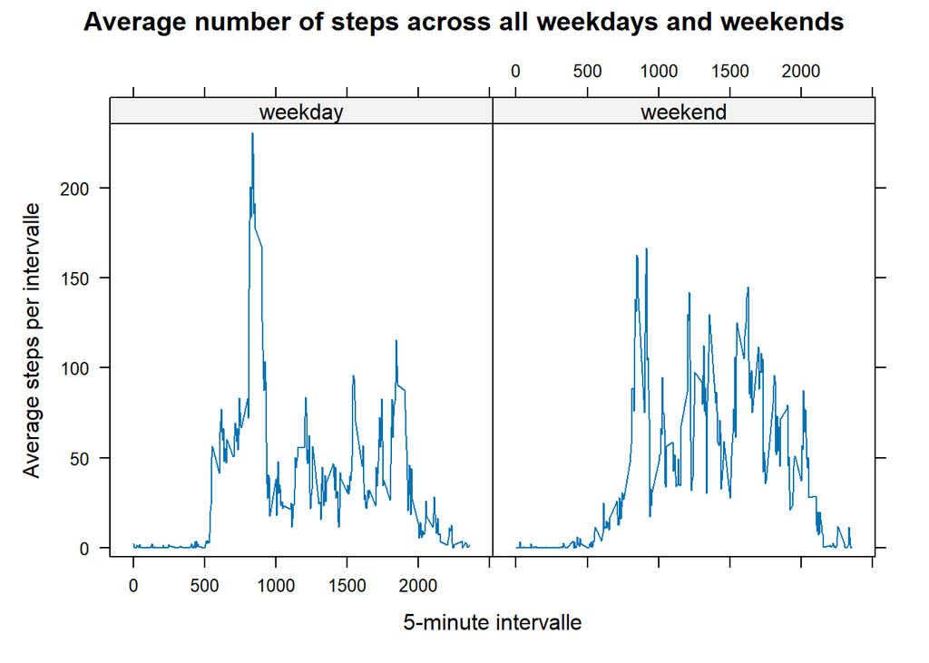

```r
dailystep_mean_impwd <- filter(data_imputed, week_weekend == "weekday")
dailystep_mean_impwd <- aggregate(dailystep_mean_impwd$imputed, list(dailystep_mean_impwd$interval), mean)
dailystep_mean_impwd$week_weekend <- "weekday"


dailystep_mean_impwkd <- filter(data_imputed, week_weekend == "weekend")
dailystep_mean_impwkd <- aggregate(dailystep_mean_impwkd$imputed, list(dailystep_mean_impwkd$interval), mean)
dailystep_mean_impwkd$week_weekend <- "weekend"

mean_imp <- rbind(dailystep_mean_impwd, dailystep_mean_impwkd)
 library(lattice)
  xyplot(mean_imp$x ~ mean_imp$Group.1 |mean_imp$week_weekend, type = "l", xlab = "5-minute intervalle", ylab = "Average steps per intervalle",
       main = "Average number of steps across all weekdays and weekends",
       ylim=c(min(mean_imp$x)-5,
              max(mean_imp$x)+5))
```

```r
png("./figure/mean_imp.png", width = 480, height = 480)
  xyplot(mean_imp$x ~ mean_imp$Group.1 |mean_imp$week_weekend, type = "l", xlab = "5-minute intervalle", ylab = "Average steps per intervalle",
       main = "Average number of steps across all weekdays and weekends",
       ylim=c(min(mean_imp$x)-5,
              max(mean_imp$x)+5))
dev.off()
```